[THE BRITISH LIONS ROAR](https://britishlionsroar.github.io/)Independent investigative opinion journalism

Political investigation · Conservative record

# CAN THE CONSERVATIVES BE BELIEVED?

FIVE PRIME MINISTERS. FOURTEEN YEARS. A TRAIL OF BROKEN PROMISES.

By **Steve English** · 12 October 2026

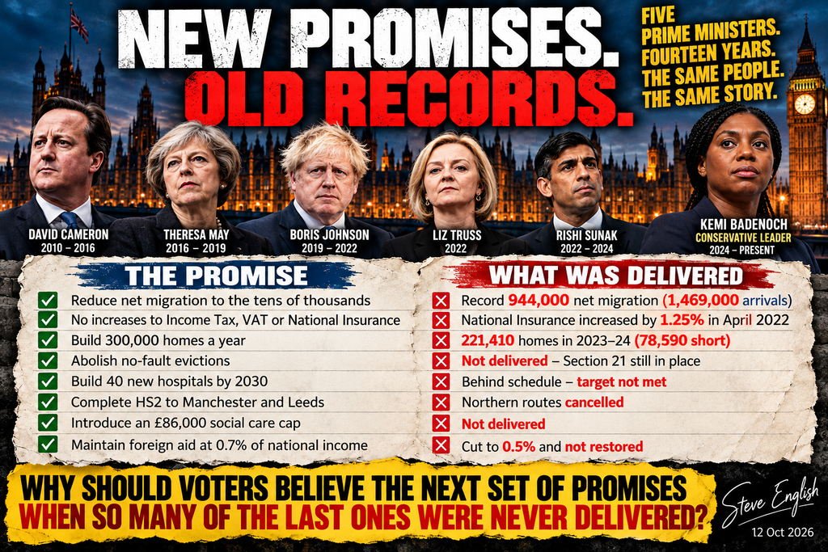

New promises. Old records. Original editorial graphic © Steve English, 12 October 2026.

David Cameron. Theresa May. Boris Johnson. Liz Truss. Rishi Sunak. Five Conservative prime ministers, fourteen years in government, and a succession of manifesto promises.

Now Kemi Badenoch leads the party, with several ministers from those governments holding senior opposition positions. Before considering the next promises, here is the record of what was pledged — and what was delivered.

Eight promises · Eight outcomes · The ministers then and now

01 / 08

## IMMIGRATION — TENS OF THOUSANDS

### THE PROMISE

Reduce annual net migration to the tens of thousands.

### WHAT WAS DELIVERED

ANNUAL NET MIGRATION REACHED 944,000 in the year ending March 2023.

### WHO WAS IN GOVERNMENT AT THE TIME?

Chris Philp — Immigration Compliance and Courts Minister, 2020–21. Now Shadow Home Secretary.

[View supporting source ↗](https://www.ons.gov.uk/peoplepopulationandcommunity/populationandmigration/internationalmigration/articles/improvinglongterminternationalmigrationstatistics/2025-11-20)

02 / 08

## NATIONAL INSURANCE — NO TAX RISE

### THE PROMISE

Do not increase National Insurance rates.

### WHAT WAS DELIVERED

NATIONAL INSURANCE ROSE BY 1.25 PERCENTAGE POINTS in April 2022.

### WHO WAS IN GOVERNMENT AT THE TIME?

Helen Whately — Exchequer Secretary to the Treasury, 2021–22. Now Shadow Work and Pensions Secretary.

[View supporting source ↗](https://www.gov.uk/government/news/national-insurance-increase-reversed)

03 / 08

## HOUSING — 300,000 A YEAR

### THE PROMISE

Deliver 300,000 additional homes a year in England by the mid-2020s.

### WHAT WAS DELIVERED

221,410 ADDITIONAL HOMES IN 2023–24. THAT IS 78,590 SHORT — 26% BELOW THE ANNUAL AMBITION.

### WHO WAS IN GOVERNMENT AT THE TIME?

Kemi Badenoch — Minister of State, Department for Levelling Up, Housing and Communities, 2021–22. Now Conservative Leader. Neil O’Brien — Parliamentary Under-Secretary in the same department, 2021–22. Now Shadow Minister for Policy Renewal.

[View supporting source ↗](https://www.gov.uk/government/statistics/housing-supply-net-additional-dwellings-england-2024-to-2025/housing-supply-net-additional-dwellings-england-2024-to-2025)

04 / 08

## NO-FAULT EVICTIONS

### THE PROMISE

Abolish Section 21 no-fault evictions.

### WHAT WAS DELIVERED

NOT DELIVERED. THE CONSERVATIVES LEFT OFFICE WITHOUT ABOLISHING SECTION 21.

### WHO WAS IN GOVERNMENT AT THE TIME?

Kemi Badenoch — Minister of State, Department for Levelling Up, Housing and Communities, 2021–22. Now Conservative Leader. Neil O’Brien — Parliamentary Under-Secretary in the same department, 2021–22. Now Shadow Minister for Policy Renewal.

[View supporting source ↗](https://commonslibrary.parliament.uk/research-briefings/cbp-10106/)

05 / 08

## 40 NEW HOSPITALS

### THE PROMISE

Build 40 new hospitals by 2030.

### WHAT WAS DELIVERED

JUST ONE OF THE 40 PROMISED SCHEMES HAD BEEN COMPLETED WHEN THE CONSERVATIVES LEFT OFFICE IN 2024.

### WHO WAS IN GOVERNMENT AT THE TIME?

Victoria Atkins — Health Secretary, 2023–24. Now Shadow Environment Secretary. Helen Whately — Social Care Minister, 2022–24. Now Shadow Work and Pensions Secretary.

[View supporting source ↗](https://fullfact.org/election-2024/streeting-atkins-40-new-hospitals/)

06 / 08

## HS2 — THE NORTHERN ROUTES

### THE PROMISE

Deliver the planned high-speed rail network connecting London, Birmingham, Manchester and Leeds.

### WHAT WAS DELIVERED

LEEDS PLANS DROPPED IN 2021. BIRMINGHAM–MANCHESTER ROUTE CANCELLED IN 2023.

### WHO WAS IN GOVERNMENT AT THE TIME?

Richard Holden — Roads and Local Transport Minister, 2022–23. Now Shadow Transport Secretary.

[View supporting source ↗](https://www.gov.uk/government/publications/department-for-transports-accounting-officer-assessment-summaries-for-the-government-major-projects-portfolio)

07 / 08

## SOCIAL CARE — THE £86,000 CAP

### THE PROMISE

Introduce an £86,000 lifetime cap on eligible personal care costs.

### WHAT WAS DELIVERED

NOT DELIVERED. THE CAP WAS NOT IMPLEMENTED BEFORE THE CONSERVATIVES LEFT OFFICE.

### WHO WAS IN GOVERNMENT AT THE TIME?

Helen Whately — Social Care Minister, 2022–24. Now Shadow Work and Pensions Secretary. Victoria Atkins — Health Secretary, 2023–24. Now Shadow Environment Secretary.

[View supporting source ↗](https://commonslibrary.parliament.uk/research-briefings/cbp-9305/)

08 / 08

## FOREIGN AID — THE 0.7% PLEDGE

### THE PROMISE

Maintain overseas development assistance at 0.7% of gross national income.

### WHAT WAS DELIVERED

CUT TO 0.5% IN 2021. THE 0.7% TARGET WAS NOT RESTORED UNDER THE CONSERVATIVES.

### WHO WAS IN GOVERNMENT AT THE TIME?

Kemi Badenoch — Exchequer Secretary to the Treasury, 2020–21. Now Conservative Leader. Helen Whately — Exchequer Secretary to the Treasury, 2021–22. Now Shadow Work and Pensions Secretary.

[View supporting source ↗](https://commonslibrary.parliament.uk/research-briefings/sn03714/)

**Five prime ministers. Fourteen years. Eight promises measured against the results.**

Badenoch offers the Conservatives a new direction. The record above is what readers have to weigh against the next manifesto.

**Can the Conservatives be believed?** The evidence is there for the public to judge.

Source notes: the hospital figure refers to the number of schemes completed under the specific 40-hospital commitment by July 2024, not a final assessment of the 2030 deadline. The housing comparison uses the 2023–24 financial year. Each section links to its supporting evidence.